info@exegetic.biz | [@exegeticdata](https://twitter.com/exegeticdata)

# Shiny: An Introduction

# Introduction

[Shiny](https://shiny.rstudio.com/) is an R package for building interactive web applications. It allows you to combine the computational power of R with the interactivity of the web.

Shiny apps are

- easy to write (no web development skills required) and
- easy to deploy.

**Resources:**

- [Shiny Cheat Sheet](https://shiny.rstudio.com/images/shiny-cheatsheet.pdf)
- [Shiny Gallery](http://shiny.rstudio.com/gallery/) (a showcase of a variety of applications built with Shiny, with source code)
- [Teach Yourself Shiny](http://shiny.rstudio.com/tutorial/) (tutorial)
- [Mastering Shiny](https://mastering-shiny.org/) (book)
- [Shiny Developer Conference](https://www.rstudio.com/resources/webinars/shiny-developer-conference/) (the first two videos on *Effective Reactive Programming* by Joe Cheng are particularly good)

## Creating a Shiny App

RStudio makes it simple to create the template for a Shiny App:

1. File → New File → Shiny Web App.

[figure not shown]

2. Choose a suitable name for the app.
3. Select either “Single File” or “Multiple File” app.
4. Select a directory in which to create the app.
5. Press Create.

You can immediately run the resulting template app by pressing Run App.

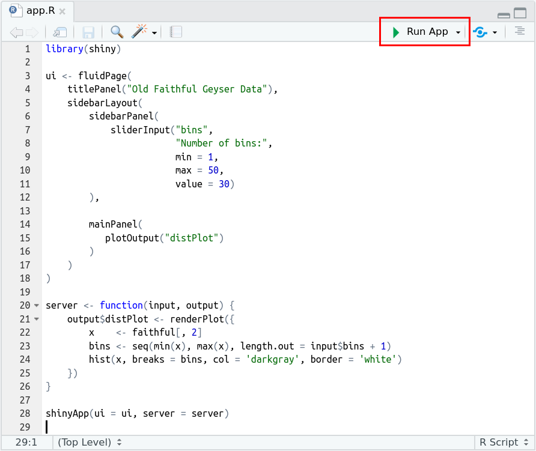

## Example: Country Populations

The set of examples can be found in the `country-populations` folder.

### Exercises

1. Run the app.
1. Open the `01-country-populations.R` script.
2. Click on “Run” in the top right corner.

2.What happens when you change the “country” selector? Is this what you expect?

3.Look at the code. Can you see why the plot is not changing?

4.Replace `"South Africa"` in the call to `filter()` with `input$country`.

5. Run a revised app.
1. Open the `02-country-populations.R` script.
2. Run the app.
6. The country names are now being retrieved from `country`. Take a look at this variable. It’s a *named* vector of country codes. The names are used for the selector but the codes are what’s returned.

Let’s deconstruct the app. Every app has two components:

1. a user interface (UI) which describes the app’s appearance and
2. a server which is where the functionality of the app is implemented.

We’ll start with the UI, which uses a `fluidPage()` page layout. This applies the [Bootstrap](https://getbootstrap.com/) principle of dividing the page into rows, which in turn are broken down into columns.

```r
ui <- fluidPage(
    titlePanel("Population Explosion"),
    sidebarLayout(
        sidebarPanel(
            selectInput(
                inputId = "country",
                label = "Country",
                choices = country,
                selected = "ZAF"
            )
        ),
        mainPanel(
            plotOutput("plot")
        )
    )
)
```

- The page is divided into two panels, “side-bar” and “main”, using `sidebarLayout()`. These two panels are populated in turn by `sidebarPanel()` and `mainPanel()`.
- Although this is not necessarily the case, input elements are usually found in the side-bar panel while output elements are located in the main panel.
- There’s a `selectInput()` input selector in the side-bar panel and a `plotOutput()` display function in the main panel.

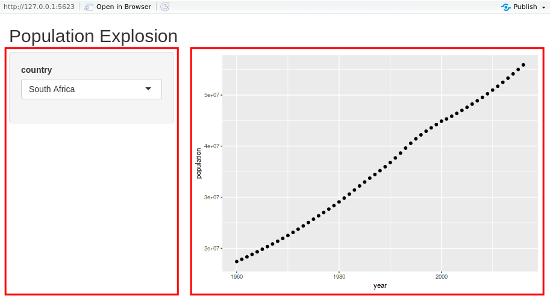

- The server generates the plot in response to changes in the country selector.
- The value of the country selector is retrieved as `input$country`.
- The name `country` comes from the `inputId` of the input selector.
- This is used to filter out only the corresponding records from the data.
- These data are then used to generate a plot. The plot is returned by the `renderPlot()` function and assigned to `output$plot`.
- The name `plot` is used to refer to this output in the UI (it’s the argument to `plotOutput()`).

```r
server <- function(input, output) {
    output$plot <- renderPlot({
        data <- populations %>% filter(code == input$country)
        ggplot(data, aes(x = year, y = population)) + geom_point()
    })
}
```

Finally the app is launched by a call to `shinyApp()`, which consumes both the UI and server.

```r
shinyApp(ui = ui, server = server)
```

## Shiny App File Layout

You can create either a “Single File” or “Multiple File” app:

- a Single File app has just one file, `app.R`, which contains both the server and UI code, but
- a Multiple File has two files, `ui.R` and `server.R`, which each contain the respective components of the app.

## Sharing Apps

[shinyapps.io](https://www.shinyapps.io/) provides a simple platform for sharing apps.

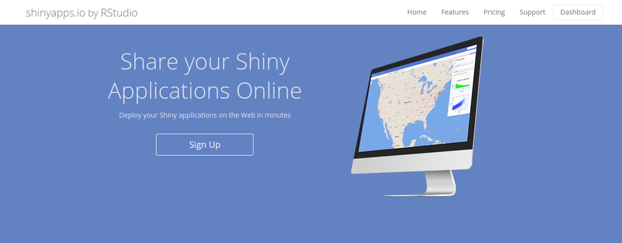

1. Go to https://www.shinyapps.io/. Press the Dashboard button.
2. Log in (create an account if you don’t yet have one).
3. Open the script for a Shiny app.
4. Press the Publish button (blue symbol in top right corner).
5. If there are multiple files listed, check only the ones relevant to the app (this includes data files!).
6. Choose an appropriate Title for the app.
7. Press the Publish button.

During the deploy process a `rsconnect/` folder will be created. Don’t delete this: it will make future deployments faster and easier.

# UI

There is great flexibility in how you lay out the interface of a Shiny application. If you are feeling particularly hard core then you can actually just code the interface in native HTML. But why punish yourself? Instead take advantage of the functionality which is built into the `shiny` package which will allow you to easily set up an attractive interface.

There are three classes of function which are used for building the interface:

- **Layout** — high level functions which dictate the overall layout of the elements in the application;
- **Input** — functions for taking application input (for example, text, checkboxes, radio buttons and dates); and
- **Output** — functions for displaying output from the server (for example, text, HTML, tables and plots).

## Input

There’s a huge range of input widgets available:

- `actionButton()`
- `actionLink()`
- `checkboxInput()` and `checkboxGroupInput()`
- `dateInput()` and `dateRangeInput()`
- `fileInput()`
- `numericInput()`
- `passwordInput()`
- `radioButtons()`
- `selectInput()`
- `slideInput()`
- `submitButton()` and
- `textInput()`.

Take a look at the [widget gallery](https://shiny.rstudio.com/gallery/widget-gallery.html) to see each of these in action.

Every input component has a unique input ID. This is how the values are referenced from the server.

### Exercises

1. Slider input.
1. Starting with `02-country-populations.R`, add a `sliderInput()` with the following characteristics:

```
* minimum = 0
* maximum = 5
* label = "Point size"
* input ID = "size"
```

2. Use the value from the size slider input to modify the point size on the plot.
2. Checkbox input.
1. Add a `checkboxInput()` with the following characteristics:

```
* label = "Plot line"
* input ID = "line"
```

2. Use the value from the line checkbox input to determine whether or not to display a line connecting the points.

If you get stuck then you can look at `03-country-populations.R`.

# Server

The server implements a single function with two parameters, `input` and `output`:

- The `input` parameter is used to reference values from the input elements in the UI.
- The `output` parameter is used to pass elements back to the UI for display.

## Output

The following rendering functions are used in the *server* to generate output:

- `renderPlot()` – a static plot
- `renderPlotly()` – an interactive plot (implemented in `{plotly}`)
- `renderLeaflet()` – an interactive map (implemented in `{leaflet}`)
- `renderTable()` – a static table
- `renderDataTable()` – an interactive table (implemented in `{DT}`)
- `renderText()`
- `renderPrint()` – captures *printed* output
- `renderImage()` and
- `renderUI()` – arbitrary UI components.

Associated with each of these is a corresponding output function which is used to display the rendered content in the *UI*.

- `plotOutput()`
- `plotlyOutput()`
- `leafletOutput()`
- `tableOutput()`
- `dataTableOutput()`
- `textOutput()`
- `verbatimTextOutput()`
- `imageOutput()` and
- `uiOutput()` or `htmlOutput()`.

A graphical representation of how some of the functions work together:

[figure not shown]

This is how it works:

- The rendering function is used to generate output, which is then assigned to a named component of `output`.
- This is then displayed by the corresponding output function in the UI, referring to it by its component name in `output`.

### Exercises

Start with `03-country-populations.R`.

1. Multiple selections.
1. In the UI enable multiple selections in the country selector.
2. In the server ensure that `filter()` doesn’t produce warnings. Hint: Replace `==` with `%in%`.
3. Use the country name to colour the points.
4. Try a logarithmic y axis.
5. Ensure that the line checkbox still works. Hint: You might need to `group` the data.

2.Scale the plot so that the y axis is in units of millions of people. Update the axis title accordingly.

Bonus: Add a (static) table which displays the most recent data for each of the selected countries.

1. Add a checkbox which determines whether or not the table is displayed. Hint: You can return `NULL` from a rendering function.
2. By default the table should be visible.

If you get stuck then you can look at `04-country-populations.R`.

There are a number of interactive output widgets:

- **Plotly** — [Plotly](https://plot.ly/) is yet another way to create great visualisations. You won’t be too surprised to learn that there is a [R interface to Plotly](https://cran.r-project.org/web/packages/plotly/index.html). Check out the [Cheat Sheet](https://images.plot.ly/plotly-documentation/images/r_cheat_sheet.pdf) for using Plotly with R and skim over the [Plotly for R User Guide](https://plot.ly/r/user-guide/) to get started. More detailed information can be found in the [Reference Guide](https://plot.ly/r/reference/).
- **HTML Widgets** — [HTML Widgets](http://www.htmlwidgets.org/) provides a framework for integrating JavaScript visualization libraries into markdown documents and Shiny Applications. Some of the packages based on [`htmlwidgets`](https://github.com/ramnathv/htmlwidgets) are listed below. Have a look at the [gallery](http://gallery.htmlwidgets.org/) to see all available options.
- **dygraphs** — Interactive time series plots can be generated using the [`dygraphs`](https://cran.r-project.org/web/packages/dygraphs/index.html) package.

```r
library(dygraphs)

dygraph(cbind(mdeaths, fdeaths)) %>% dyRangeSelector()
```

[interactive chart not shown]

- **networkD3** — The [`networkD3`](https://cran.r-project.org/web/packages/networkD3/index.html) package provides ways to visualise networks. The example below is a simple illustrative example. There are a variety of more complex visualisations possible with this package. Check out the [project homepage](http://christophergandrud.github.io/networkD3/) for more examples.

```r
library(networkD3)

networkData <- data.frame(
  src = c("A", "A", "A", "A", "B", "B", "C", "C", "D"),
  target = c("B", "C", "D", "J", "E", "F", "G", "H", "I")
)

simpleNetwork(networkData)
```

[interactive chart not shown]

- **DT** — The [`DT`](https://cran.r-project.org/web/packages/DT/index.html) package makes beautifully formatted tables.

```r
library(DT)

datatable(iris)
```

|  | Sepal.Length | Sepal.Width | Petal.Length | Petal.Width | Species |
| --- | --- | --- | --- | --- | --- |
| 1 | 5.1 | 3.5 | 1.4 | 0.2 | setosa |
| 2 | 4.9 | 3 | 1.4 | 0.2 | setosa |
| 3 | 4.7 | 3.2 | 1.3 | 0.2 | setosa |
| 4 | 4.6 | 3.1 | 1.5 | 0.2 | setosa |
| 5 | 5 | 3.6 | 1.4 | 0.2 | setosa |
| 6 | 5.4 | 3.9 | 1.7 | 0.4 | setosa |
| 7 | 4.6 | 3.4 | 1.4 | 0.3 | setosa |
| 8 | 5 | 3.4 | 1.5 | 0.2 | setosa |
| 9 | 4.4 | 2.9 | 1.4 | 0.2 | setosa |
| 10 | 4.9 | 3.1 | 1.5 | 0.1 | setosa |

[output cut: 140 more lines]

- **Leaflet** — Interactive maps from OpenStreetMap generated by [Leaflet](http://leafletjs.com/) can be integrated into a Shiny application. Read [Using Leaflet with Shiny](https://rstudio.github.io/leaflet/shiny.html) to find out more.

```r
library(leaflet)

leaflet() %>%
  addTiles() %>%
  setView(18.424, -33.925, zoom = 13) %>%
  addMarkers(lng = 18.418907, lat = -33.906975)
```

[interactive chart not shown]

### Exercises

1. Replace the static table with an interactive [DataTable](https://datatables.net/).

```
- Use `renderDataTable()` in the server.
- Use `dataTableOutput()` in the UI.
```

2. Replace the static plot with an interactive [Plotly](https://plot.ly/).

```
- Use `renderPlotly()` in the server.
- Use `plotlyOutput()` in the UI.
```

If you get stuck then you can look at `05-country-populations.R`.